# Introduction to R

#### Visualization with `ggplot2`

R has three core plotting systems, `base`, `lattice` and `ggplot2`. In this course we’re going to use a plotting library called `ggplot2` because I think it produces the best plots, and uses a syntax that is more consistent and reusable than base R graphics.

If you’re familiar with R’s `base` graphics then [qplot()](http://docs.ggplot2.org/0.9.3.1/qplot.html) will seem natural. Feel free to read up on `qplot()` and its uses, but we’re going to focus primarily on the `ggplot` function for constructing graphics.

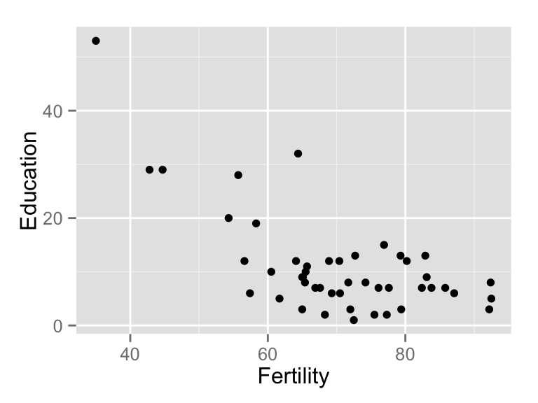

```r
qplot(Fertility, Education, data = swiss)
```

Plots in `ggplot2` are made up of *aesthetics* and *geoms*.

The components of a `ggplot` are * input data * aesthetic mappings * geoms * facets - optional * stats * scales * coordinate system

Every ggplot starts with a line like this: `ggplot(dataframe, aes(x = var1, y = var2, ...))` that maps data onto x and y dimensions for our plot, yet to be defined.

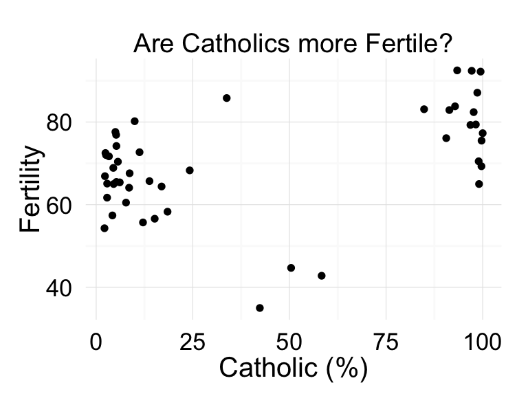

```r
# scatter plot
ggplot(swiss, aes(x = Catholic, y = Fertility)) +
  # data mapping
  geom_point() + # draw a scatter plot
  # plot labeling
  scale_x_continuous('Catholic (%)') +
  scale_y_continuous('Fertility') +
  # theme elements
  ggtitle('Are Catholics more Fertile?') +
  theme_minimal() + # simpler colors. how does it look if you remove it?
  theme(
    axis.text.x = element_text(size = 13),
    axis.text.y = element_text(size = 13),
    title = element_text(size = 12),
    axis.title = element_text(size = 15),
    axis.ticks = element_blank())
```

Think of ggplots as being built up as layers. First we map the variables with the ggplot statement, then we tell ggplot what type of plot to make (e.g. scatter, histogram, bar plot, etc). Finally, we can layer on nice labels, colors and annotation. I highly recommend having this page up when plotting: http://docs.ggplot2.org/

```
## stat_bin: binwidth defaulted to range/30. Use 'binwidth = x' to adjust this.
```

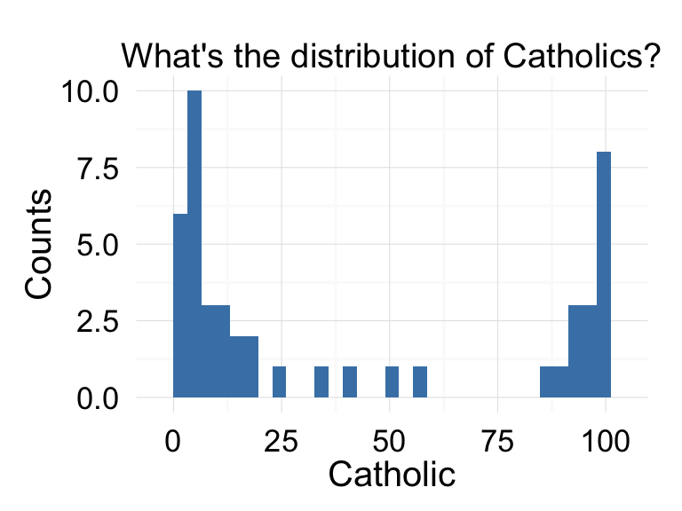

```r
# histogram
ggplot(swiss, aes(x = Catholic)) +
  # data mapping
  geom_histogram(fill = 'steelblue') + #
  # plot labeling
  scale_x_continuous('Catholic') +
  scale_y_continuous('Counts') +
  # theme elements
  ggtitle("What's the distribution of Catholics?") +
  theme_minimal() +
  theme(
    axis.text.x = element_text(size = 13),
    axis.text.y = element_text(size = 13),
    title = element_text(size = 12),
    axis.title = element_text(size = 15),
    axis.ticks = element_blank())
```

See how much of that code we were able to reuse?